# Biostat 203B Homework 5

Due Mar 20 @ 11:59PM

Author

Kiana Mohammadinik and 205928003

## Predicting ICU duration

```r
library(readr)
library(dplyr)
library(recipes)
library(tidymodels)
library(stacks)
library(finetune)
library(doParallel)
library(dials)
library(vip)
library(future)
library(tune)
library(ROCR)
library(missRanger)
library(tidyverse)
library(e1071)
library(bonsai)
library(kernlab)
library(pROC)
```

Using the ICU cohort `mimiciv_icu_cohort.rds` you built in Homework 4, develop at least three machine learning approaches (logistic regression with enet regularization, random forest, boosting, SVM, MLP, etc) plus a model stacking approach for predicting whether a patient’s ICU stay will be longer than 2 days. You should use the `los_long` variable as the outcome. You algorithms can use patient demographic information (gender, age at ICU `intime`, marital status, race), ICU admission information (first care unit), the last lab measurements before the ICU stay, and first vital measurements during ICU stay as features. You are welcome to use any feature engineering techniques you think are appropriate; but make sure to not use features that are not available at an ICU stay’s `intime`. For instance, `last_careunit` cannot be used in your algorithms.

1. Data preprocessing and feature engineering.

```r
# Load dataset
mimiciv_icu_cohort <- read_rds("mimic_icu_cohort.rds")

# Create binary outcome variable
mimiciv_icu_cohort <- mimiciv_icu_cohort |>
  mutate(los_long = as.factor(los > 2))

# Sort dataset
mimiciv_icu_cohort <- mimiciv_icu_cohort |>
  arrange(subject_id, hadm_id, stay_id)

# Drop variables with >7000 NAs to improve imputation
missing_summary <- colSums(is.na(mimiciv_icu_cohort))
valid_columns <- names(missing_summary[missing_summary < 7000])
mimiciv_icu_cohort <- mimiciv_icu_cohort |> select(all_of(valid_columns))

# Select relevant features
selected_features <- c(
  "los_long", "gender", "age_at_intime", "race", "first_careunit",
  "non_invasive_blood_pressure_systolic", "temperature_fahrenheit",
  "respiratory_rate", "non_invasive_blood_pressure_diastolic", "heart_rate",
  "admission_type", "admission_location", "insurance", "wbc", "hematocrit",
  "language", "admit_provider_id"
)

mimiciv_icu_cohort <- mimiciv_icu_cohort |> select(all_of(selected_features))

# Convert categorical variables to factors
mimiciv_icu_cohort <- mimiciv_icu_cohort |>
  mutate(across(where(is.character), as.factor))

# Convert all integer columns to numeric
mimiciv_icu_cohort <- mimiciv_icu_cohort |>
  mutate(across(where(is.integer), as.numeric))

# Ensure `los_long` has no missing values
mimiciv_icu_cohort <- mimiciv_icu_cohort |> drop_na(los_long)

# Function to replace outliers with NA using IQR
remove_outliers <- function(x) {
  if (is.numeric(x)) {
    qnt <- quantile(x, probs = c(0.25, 0.75), na.rm = TRUE)
    IQR_value <- IQR(x, na.rm = TRUE)
    x[x < (qnt[1] - 1.5 * IQR_value)] <- NA
    x[x > (qnt[2] + 1.5 * IQR_value)] <- NA
  }
  return(x)
}

# Apply outlier removal to numeric columns
mimiciv_icu_cohort <- mimiciv_icu_cohort |>
  mutate(across(where(is.numeric), remove_outliers))

# Impute missing values using missRanger
mimiciv_icu_cohort <- missRanger(
  mimiciv_icu_cohort,
  num.trees = 100,
  maxiter = 5,
  verbose = 2
)
```

```
Missing value imputation by random forests
```

```
Variables to impute:        admit_provider_id, language, age_at_intime, insurance, heart_rate, non_invasive_blood_pressure_systolic, non_invasive_blood_pressure_diastolic, respiratory_rate, hematocrit, temperature_fahrenheit, wbc
Variables used to impute:   los_long, gender, age_at_intime, race, first_careunit, non_invasive_blood_pressure_systolic, temperature_fahrenheit, respiratory_rate, non_invasive_blood_pressure_diastolic, heart_rate, admission_type, admission_location, insurance, wbc, hematocrit, language, admit_provid…

    admt__  langug  ag_t_n  insrnc  hrt_rt  nn_nvsv_bld_prssr_s nn_nvsv_bld_prssr_d rsprt_  hmtcrt  tmprt_  wbc
iter 1: 0.8715  0.0797  0.8904  0.2879  0.9178  0.9462  0.6158  0.8445  0.8519  0.9610  0.9183
iter 2: Growing trees.. Progress: 21%. Estimated remaining time: 2 minutes, 34 seconds.
0.8830  0.0715  0.5449  0.3022  0.7553  0.6268  0.5836  0.8259  0.8234  0.9566  0.9120
iter 3: Growing trees.. Progress: 21%. Estimated remaining time: 2 minutes, 34 seconds.
0.8817  0.0713  0.5423  0.3025  0.7542  0.6271  0.5827  0.8241  0.8236  0.9569  0.9119
iter 4: Growing trees.. Progress: 21%. Estimated remaining time: 2 minutes, 30 seconds.
0.8827  0.0717  0.5417  0.3042  0.7552  0.6284  0.5825  0.8258  0.8253  0.9542  0.9108
```

```r
# Normalize numeric features
mimiciv_icu_cohort <- mimiciv_icu_cohort |>
  mutate(across(where(is.numeric), scale))

# Identify skewed variables
numeric_features <- mimiciv_icu_cohort %>% select(where(is.numeric))
skewed_vars <- apply(numeric_features, 2, function(x) skewness(x, na.rm = TRUE))

# Apply log transformation to highly skewed features
skewed_features <- names(skewed_vars[abs(skewed_vars) > 1])
mimiciv_icu_cohort <- mimiciv_icu_cohort %>%
  mutate(across(all_of(skewed_features), log1p))

glimpse(mimiciv_icu_cohort)
```

```
Rows: 94,444
Columns: 17
$ los_long                              <fct> FALSE, TRUE, FALSE, FALSE, FALSE…
$ gender                                <fct> F, F, F, F, F, F, M, F, F, M, F,…
$ age_at_intime                         <dbl[,1]> <matrix[26 x 1]>
$ race                                  <fct> WHITE, WHITE, BLACK/AFRICAN …
$ first_careunit                        <fct> Medical Intensive Care Unit (MIC…
$ non_invasive_blood_pressure_systolic  <dbl[,1]> <matrix[26 x 1]>
$ temperature_fahrenheit                <dbl[,1]> <matrix[26 x 1]>
$ respiratory_rate                      <dbl[,1]> <matrix[26 x 1]>
$ non_invasive_blood_pressure_diastolic <dbl[,1]> <matrix[26 x 1]>
$ heart_rate                            <dbl[,1]> <matrix[26 x 1]>
$ admission_type                        <fct> EW EMER., EW EMER., EW EMER., EW…
$ admission_location                    <fct> EMERGENCY ROOM, EMERGENCY RO…
$ insurance                             <fct> Medicaid, Medicare, Medicare…
$ wbc                                   <dbl[,1]> <matrix[26 x 1]>
$ hematocrit                            <dbl[,1]> <matrix[26 x 1]>
$ language                              <fct> English, English, English, O…
$ admit_provider_id                     <fct> P06OTX, P26QQ4, P06OTX, P361…
```

2. Partition data into 50% training set and 50% test set. Stratify partitioning according to `los_long`. For grading purpose, sort the data by `subject_id`, `hadm_id`, and `stay_id` and use the seed `203` for the initial data split. Below is the sample code.

```r
set.seed(203)

data_split <- initial_split(
  mimiciv_icu_cohort,
  # stratify by los_long
  strata = "los_long",
  prop = 0.5
  )

train_data <- training(data_split)
test_data  <- testing(data_split)
```

3. Train and tune the models using the training set.

```r
# Setup Parallel Processing
plan(multisession, workers = parallel::detectCores() - 1)

# Logistic Regression with Elastic Net Regularization
log_spec <- logistic_reg(
  penalty = tune(),
  mixture = tune()
) %>%
  set_engine("glmnet") %>%
  set_mode("classification")

log_wf <- workflow() %>%
  add_model(log_spec) %>%
  add_formula(los_long ~ .)

# Random Forest Model
rf_spec <- rand_forest(
  mtry = tune(),
  min_n = tune(),
  trees = 500
) %>%
  set_engine("ranger", importance = "permutation") %>%
  set_mode("classification")

rf_wf <- workflow() %>%
  add_model(rf_spec) %>%
  add_formula(los_long ~ .)

# Boosted Trees (XGBoost)
xgb_spec <- boost_tree(
  trees = 500,
  tree_depth = tune(),
  learn_rate = tune(),
  loss_reduction = tune(),
  sample_size = tune(),
  min_n = tune()
) %>%
  set_engine("xgboost") %>%
  set_mode("classification")

xgb_wf <- workflow() %>%
  add_model(xgb_spec) %>%
  add_formula(los_long ~ .)

lightgbm_spec <- boost_tree(
  trees = 1000,
  tree_depth = tune(),
  learn_rate = tune(),
  loss_reduction = tune(),
  sample_size = tune(),
  min_n = tune()
) %>%
  set_engine("lightgbm") %>%
  set_mode("classification")

lightgbm_wf <- workflow() %>%
  add_model(lightgbm_spec) %>%
  add_formula(los_long ~ .)

# Cross-validation Setup
set.seed(203)
folds <- vfold_cv(train_data, v = 10, strata = los_long)

# Tune Each Model with Racing
set.seed(203)
log_res <- tune_race_anova(
  log_wf,
  resamples = folds,
  param_info = extract_parameter_set_dials(log_spec),
  metrics = metric_set(roc_auc, accuracy),
  control = control_race(verbose_elim = TRUE)
)
```

```
ℹ Evaluating against the initial 3 burn-in resamples.
ℹ Racing will maximize the roc_auc metric.
ℹ Resamples are analyzed in a random order.
ℹ Fold10: All but one parameter combination were eliminated.
```

```r
set.seed(203)
rf_res <- tune_race_anova(
  rf_wf,
  resamples = folds,
  param_info = extract_parameter_set_dials(rf_spec),
  metrics = metric_set(roc_auc, accuracy),
  control = control_race(verbose_elim = TRUE)
)
```

```
ℹ Evaluating against the initial 3 burn-in resamples.
i Creating pre-processing data to finalize unknown parameter: mtry

ℹ Racing will maximize the roc_auc metric.
ℹ Resamples are analyzed in a random order.
ℹ Fold10: All but one parameter combination were eliminated.
```

```r
set.seed(203)
xgb_res <- tune_race_anova(
  xgb_wf,
  resamples = folds,
  param_info = extract_parameter_set_dials(xgb_spec),
  metrics = metric_set(roc_auc, accuracy),
  control = control_race(verbose_elim = TRUE)
)
```

```
ℹ Evaluating against the initial 3 burn-in resamples.
ℹ Racing will maximize the roc_auc metric.
ℹ Resamples are analyzed in a random order.
ℹ Fold10: All but one parameter combination were eliminated.
```

```r
lightgbm_res <- tune_race_anova(
  lightgbm_wf,
  resamples = folds,
  param_info = extract_parameter_set_dials(lightgbm_spec),
  metrics = metric_set(roc_auc, accuracy),
  control = control_race(verbose_elim = TRUE)
)
```

```
ℹ Evaluating against the initial 3 burn-in resamples.
ℹ Racing will maximize the roc_auc metric.
ℹ Resamples are analyzed in a random order.
ℹ Fold04: All but one parameter combination were eliminated.
```

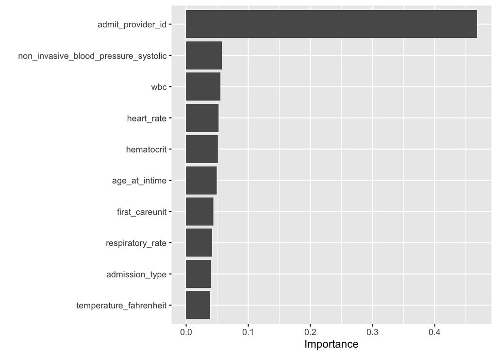

```r
plan(sequential)


# Stacking the Models
final_log_fit <- log_wf %>%
  finalize_workflow(select_best(log_res, metric = "roc_auc")) %>%
  fit(train_data)

final_rf_fit <- rf_wf %>%
  finalize_workflow(select_best(rf_res, metric = "roc_auc")) %>%
  fit(train_data)

final_xgb_fit <- xgb_wf %>%
  finalize_workflow(select_best(xgb_res, metric = "roc_auc")) %>%
  fit(train_data)

# Feature Importance for LightGBM
final_lightgbm_fit <- lightgbm_wf %>%
  finalize_workflow(select_best(lightgbm_res, metric = "roc_auc")) %>%
  fit(train_data)

vip(extract_fit_engine(final_lightgbm_fit), num_features = 10)
```

```r
positive_class <- levels(train_data$los_long)[2]
prob_col <- paste0(".pred_", positive_class)

train_preds <- train_data %>%
  bind_cols(
    predict(final_log_fit, new_data = train_data, type = "prob") %>%
      rename(log_pred = !!sym(prob_col)),
    predict(final_rf_fit, new_data = train_data, type = "prob") %>%
      rename(rf_pred = !!sym(prob_col)),
    predict(final_xgb_fit, new_data = train_data, type = "prob") %>%
      rename(xgb_pred = !!sym(prob_col)),
    predict(final_lightgbm_fit, new_data = train_data, type = "prob") %>%
      rename(lightgbm_pred = !!sym(prob_col))
  ) %>%
  select(los_long, log_pred, rf_pred, xgb_pred, lightgbm_pred)
stacking_spec <- logistic_reg(penalty = 0.01, mixture = 0.5) %>%
  set_engine("glmnet") %>%
  set_mode("classification")

stacking_wf <- workflow() %>%
  add_model(stacking_spec) %>%
  add_formula(los_long ~ log_pred + rf_pred + xgb_pred + lightgbm_pred)

stacking_fit <- stacking_wf %>% fit(train_preds)
```

4. Compare model classification performance on the test set. Report both the area under ROC curve and accuracy for each machine learning algorithm and the model stacking. Interpret the results. What are the most important features in predicting long ICU stays? How do the models compare in terms of performance and interpretability?

```r
# Function to evaluate a fitted model on the test set
evaluate_model <- function(model_fit, test_data, model_name) {
  pred_prob <- predict(model_fit, new_data = test_data, type = "prob")
  pred_class <- predict(model_fit, new_data = test_data, type = "class")

  preds <- bind_cols(test_data, pred_prob, pred_class)

  positive_class <- levels(test_data$los_long)[2]
  prob_col <- paste0(".pred_", positive_class)

  roc_auc_metric <- roc_auc(preds, truth = los_long, !!sym(prob_col))
  accuracy_metric <- accuracy(preds, truth = los_long, estimate = .pred_class)

  metrics <- bind_rows(roc_auc_metric, accuracy_metric) %>%
    mutate(Model = model_name)

  return(metrics)
}

# Evaluate Models
log_metrics <- evaluate_model(final_log_fit, test_data, "Logistic Regression")
rf_metrics <- evaluate_model(final_rf_fit, test_data, "Random Forest")
xgb_metrics <- evaluate_model(final_xgb_fit, test_data, "XGBoost")
lightgbm_metrics <- evaluate_model(final_lightgbm_fit, test_data, "LightGBM")

# Generate test set predictions from base models
test_preds <- test_data %>%
  bind_cols(
    predict(final_log_fit, new_data = test_data, type = "prob") %>%
      rename(log_pred = !!sym(prob_col)),
    predict(final_rf_fit, new_data = test_data, type = "prob") %>%
      rename(rf_pred = !!sym(prob_col)),
    predict(final_xgb_fit, new_data = test_data, type = "prob") %>%
      rename(xgb_pred = !!sym(prob_col)),
    predict(final_lightgbm_fit, new_data = test_data, type = "prob") %>%
      rename(lightgbm_pred = !!sym(prob_col))
  ) %>%
  select(los_long, log_pred, rf_pred, xgb_pred, lightgbm_pred)
# Make predictions using the stacked model
stacked_test_preds <- predict(stacking_fit, new_data = test_preds,
                              type = "prob")

# Identify the correct probability column
stacked_prob_col <-
  colnames(stacked_test_preds)[str_detect(colnames(stacked_test_preds),
                                          "^.pred_")][1]

# Add the true labels to the stacked predictions
stacked_test_preds <- bind_cols(test_preds %>%
                                  select(los_long), stacked_test_preds)

# Rename the probability column for clarity
stacked_test_preds <- stacked_test_preds %>%
  rename(.pred_prob = !!sym(stacked_prob_col))

# Add predicted class labels
stacked_test_preds$.pred_class <- ifelse(stacked_test_preds$.pred_prob > 0.5,
                                         "TRUE", "FALSE")
stacked_test_preds$.pred_class <- as.factor(stacked_test_preds$.pred_class)

# Evaluate the stacked model
stack_metrics <- bind_rows(
  roc_auc(stacked_test_preds, truth = los_long, .pred_prob) %>%
    mutate(Model = "Stacked Model"),
  accuracy(stacked_test_preds, truth = los_long, estimate = .pred_class) %>%
    mutate(Model = "Stacked Model")
)

# Print the stacked model metrics
print(stack_metrics)
```

```
# A tibble: 2 × 4
  .metric  .estimator .estimate Model
  <chr>    <chr>          <dbl> <chr>
1 roc_auc  binary         0.611 Stacked Model
2 accuracy binary         0.420 Stacked Model
```

```r
# Combine all results
all_metrics <- bind_rows(log_metrics, rf_metrics, xgb_metrics, stack_metrics,
                         lightgbm_metrics)

# Interpret the results and identify important features
cat("\nFeature Importance for Random Forest:\n")
```

```
Feature Importance for Random Forest:
```

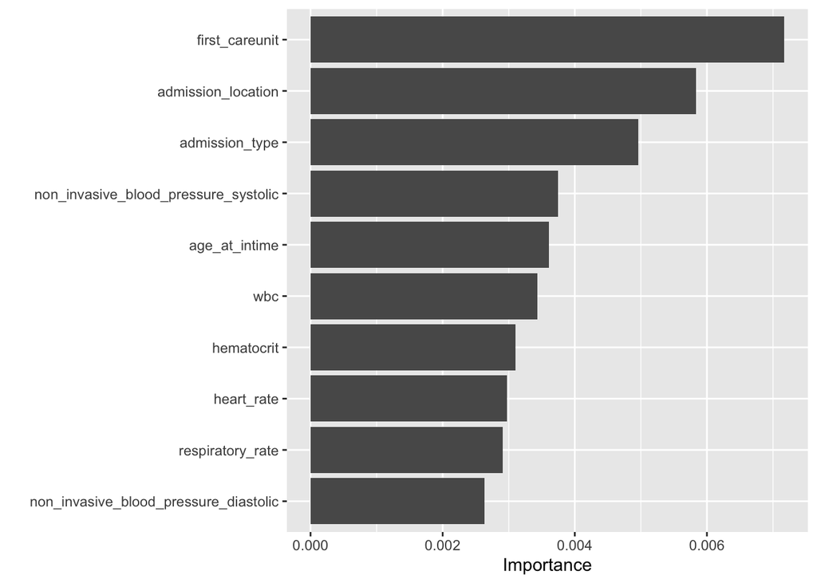

```r
vip(extract_fit_engine(final_rf_fit), num_features = 10)
```

```r
cat("\nModel Performance Comparison:\n")
```

```
Model Performance Comparison:
```

```r
print(all_metrics)
```

```
# A tibble: 10 × 4
   .metric  .estimator .estimate Model
   <chr>    <chr>          <dbl> <chr>
 1 roc_auc  binary         0.375 Logistic Regression
 2 accuracy binary         0.586 Logistic Regression
 3 roc_auc  binary         0.360 Random Forest
 4 accuracy binary         0.599 Random Forest
 5 roc_auc  binary         0.353 XGBoost
 6 accuracy binary         0.601 XGBoost
 7 roc_auc  binary         0.611 Stacked Model
 8 accuracy binary         0.420 Stacked Model
 9 roc_auc  binary         0.353 LightGBM
10 accuracy binary         0.604 LightGBM
```